# BUDT704_Group10_FinalReport

###### **Group**: 10 (Pythonic Playlisteners)

###### **Course**: BUDT704

###### **Section**: 0501

###### **Date**: 12/06/21

## Introduction

From audio cassettes to vinyl disks, from ipods to itunes, as media products shift from physical goods to bits, the way people explore and perceive new media has also changed through the years.

The amount of data people consume every day makes it a necessity for digital companies to fine tune their selling for each user in order to create a hyper personalised environment for users to be more engaged.

Spotify, an online music streaming platform, puts user personalization at the forefront through recommended playlists. Rather than just listening to a full length album, users are able to control their experience by curating playlists that can reflect their emotions, activities, and memories. Spotify can enhance this personalization experience by assisting users in their music discovery. Discovering new tracks are made easier by offering recommendations relevant to the user.

What sets Spotify apart from other music streaming platforms like Amazon Music, Pandora, Apple Music, and YT Music is precisely the spot on recommendations that it offers users for their playlists. Through this project, we aim to see how any platform can improve its user personalization and its implications for the future of targetted marketing.

### Objective

For this project we will be building a recommendation system which recommends 20 songs that a user might add to their playlist based on the first song added by the user. This recommendation system can be leveraged by platforms to further refine the precision of their recommendations to users and ensure that customers stay loyal to their platform.

In order to achieve this, we will try to analyze the data in order to find trends in user listening habits. We will also see who are the top artists, what are the top genres, and what sets them apart from the rest. These analysis will not only help us to optimize our recommendation system but can help all the sides of the platform involved in the following ways:

- **Users** : To get personalized recommendations based on their listening history
- **Artists** : To include particular attributes to make their song a hit
- **Streaming Platforms** : To promote in-house curated playlists based on genres people like
- **Record Labels and Music Distributors** : To sign contracts with artists who are leading the music industry

### Dataset

Our analysis was done on an existing dataset obtained from a Spotify Case Challenge - **Million Playlist Dataset Challenge**, hosted by [AIcrowd](https://www.aicrowd.com/challenges/spotify-million-playlist-dataset-challenge) in **JSON** format. This dataset consists of 1 million Spotify playlists and is sampled from over 4 billion public playlists on Spotify. This sampled dataset further consists of over 2 million unique tracks by nearly 300,000 artists and represents the largest public dataset of music playlists in the world. The dataset includes public playlists created by US Spotify users between January 2010 and November 2017. Playlists are sampled with simple randomization, are manually filtered for playlist quality and to remove offensive content and have some dithering and fictitious tracks added to them. As such, the dataset is not representative of the true distribution of playlists on the Spotify platform and must not be interpreted as such in any research or analysis performed on the dataset. The data is anonymized to protect user privacy by Spotify.

However, Our analysis was done only on the **first 1000 playlists and their respective songs** to serve the purpose of this project. The dataset contains the following attributes:

- **Playlist Data**
  - Playlist title
  - Collaborations
  - Playlist ID
  - Time modified
  - Number of Tracks
  - Number of albums
  - Number of followers
- **Track Data**
  - Track Uniform Resource Indicator (URI)
  - Artist URI
  - Track name
  - Album Uniform Resource Indicator
  - Duration of track

As we wanted to dig deeper in order to find out what separates each track from the rest and to optimize the recommendation system, we decided to pull data for each individual track by making **API calls** to [Spotify Data Catalogue](https://developer.spotify.com/documentation/web-api/) using **REST principles**. This dataset was acquired in **JSON** format and contains the following attributes:

- **Artist Objects**
  - Genres
  - Popularity
- **Audio Features Objects**
  - Acousticness
    - Measures whether the track is acoustic
  - Danceability
    - Measures danceability based on elements such as tempo, rhythm stability, beat strength
  - Energy
    - The perceptual measure of intensity and activity. Higher measurement indicates the track is more energetic
  - Instrumentalness
    - Indicates whether a track contains clear vocals. Higher value indicates that the track contains less or no vocals
  - Liveness
    - Measures the presence of an audience in the recording
  - Mode
    - Measures the modality, which is the scale of track (major or minor). Major is 1 and Minor is 0
  - Speechiness
    - Measures the presence of spoken words. Higher value indicates higher change of speech recording
  - Tempo
    - Measures the BPM (Beats Per Minute) of a track
  - Valence
    - Measures the “musical positiveness conveyed.” High values indicate more positive feelings (such as happiness or excitement), and lower values indicate more negative feelings (such as depressed or angry)
      - Loudness
      - Indicated the loudness of the track
      - Key
      - Indicates the chord progression of the track
      - Time Signature
      - Indicates the number of counts in each measure

Sources : [Spotify for Developers](https://developer.spotify.com/documentation/web-api/quick-start/)

## Data Analysis over Data Processing

Our data processing centers around an existing dataset obtained from a Spotify Case Challenge - **Million Playlist Dataset Challenge**, which needed minimal data processing. However, this data wasn't enough to answer our questions of interest. The team decided to dig deeper into the analysis based on the metadata of each song in a playlist which wasn't available in the above mentioned dataset. This metadata was obtained by making **API calls** to Spotify Data Catalogue using **REST principles**.

*With playlist data and song metadata in hand, the team was able to analyze and answer the questions of interest in more detail. The data analysis was based upon datapoints which were personalized and varied for each user. Thus, the team believes that the data analysis portion is more weighted compared to the data processing portion, and choose to have a **heavier grading on data analysis**.*

Data Source : [Spotify Dataset](https://www.aicrowd.com/challenges/spotify-million-playlist-dataset-challenge)  
Metadata Source : [Spotify for Developers](https://developer.spotify.com/documentation/web-api/)

## Importing Libraries For Data Processing

Apart from the standard libraries like pandas, numpy, datatime, matplotlib, seaborn, and plotly, we will be using the following additional resources for processing the data:

- **requests**: Used for the Spotify API requests
- **json**: To load and dump the data from the json files in the Million Playlist Data
- **time**: Used to create a delay in the Spotify API calls and prevent reaching the rate limit
- **os**: Used to check if the file track_info.json exists
- **ast**: It is used to interact with the Python code in order to modify it
- **MinMaxScaler**: It is used to scale the data
- **Display**: Give support for interactive data visualization and use of GUI toolkits.

```python
import requests
import json
import pandas as pd
import time
import os
import numpy as np
import ast
import matplotlib.pyplot as plt
import seaborn as sns
from sklearn.preprocessing import MinMaxScaler
import plotly.graph_objects as go
from datetime import datetime
from IPython.display import display
from scipy import spatial
```

## Data Processing

Before analysing the data, we will prepare our data in order to answer our questions of interest. The data processing will be divided into **4** stages:

- **Data Extraction**
- **Data Cleaning**
- **Data Wrangling**
- **Data Merging**

We will be explaining each stage in detail as we go about it.

### Data Extraction - Playlist Data

**The Million Playlist Challenge Dataset** consists of playlists and their respective tracks in **json** format. We will be loading this data into a data frame while setting a **unique identifier** for each playlist as its index. Since the tracks are included as lists within the playlist, we will be extracting them later in order to display the track information separately before we dig deeper into the track metadata.

```python
# Reading and loading the json file into a dataframe
playlist_file = 'playlist_data.json'
with open(playlist_file,'r') as j:
     playlist_df = json.loads(j.read())

# flattening the list data
playlist_df = pd.json_normalize(playlist_df)['playlists']
playlist_df = pd.DataFrame(playlist_df[0])

# Setting playlist id as index
playlist_df.set_index('pid',inplace = True)

# Displaying the dataframe
playlist_df.head(10)
```

| pid | name | collaborative | modified_at | num_tracks | num_albums | num_followers | tracks | num_edits | duration_ms | num_artists | description |
| --- | --- | --- | --- | --- | --- | --- | --- | --- | --- | --- | --- |
| 0 | Throwbacks | false | 1493424000 | 52 | 47 | 1 | [{'pos': 0, 'artist_name': 'Missy Elliott', 't... | 6 | 11532414 | 37 | NaN |
| 1 | Awesome Playlist | false | 1506556800 | 39 | 23 | 1 | [{'pos': 0, 'artist_name': 'Survivor', 'track_... | 5 | 11656470 | 21 | NaN |
| 2 | korean | false | 1505692800 | 64 | 51 | 1 | [{'pos': 0, 'artist_name': 'Hoody', 'track_uri... | 18 | 14039958 | 31 | NaN |
| 3 | mat | false | 1501027200 | 126 | 107 | 1 | [{'pos': 0, 'artist_name': 'Camille Saint-Saën... | 4 | 28926058 | 86 | NaN |
| 4 | 90s | false | 1401667200 | 17 | 16 | 2 | [{'pos': 0, 'artist_name': 'The Smashing Pumpk... | 7 | 4335282 | 16 | NaN |
| 5 | Wedding | false | 1430956800 | 80 | 71 | 1 | [{'pos': 0, 'artist_name': 'Cali Swag District... | 3 | 19156557 | 56 | NaN |
| 6 | I Put A Spell On You | false | 1477094400 | 16 | 15 | 1 | [{'pos': 0, 'artist_name': 'Creedence Clearwat... | 2 | 3408479 | 13 | NaN |
| 7 | 2017 | false | 1509321600 | 53 | 52 | 1 | [{'pos': 0, 'artist_name': 'Fink', 'track_uri'... | 38 | 12674796 | 48 | NaN |
| 8 | BOP | false | 1508976000 | 46 | 37 | 2 | [{'pos': 0, 'artist_name': 'Catfish and the Bo... | 21 | 9948921 | 23 | NaN |
| 9 | old country | false | 1501804800 | 21 | 20 | 1 | [{'pos': 0, 'artist_name': 'Willie Nelson', 't... | 10 | 4297488 | 18 | NaN |

### Data Wrangling - Playlist Data

In order to get best results, We will be transforming and mapping our data from its original form into our desired format with the intent of making it more appropriate and valuable for our analysis. To achieve this, we will be converting timestamp of playlist modification from **UTC format** into **datetime format**, extracting only the year.

```python
# Converting UTC Unix Epoch format into datetime format
playlist_df['modified_year'] = playlist_df['modified_at'].apply(lambda x: datetime.fromtimestamp(x))

# Converting datetime into string and extracting the year
playlist_df['modified_year'] = playlist_df['modified_year'].astype(str)
playlist_df['modified_year'] = playlist_df['modified_year'].str.split("-").str[0]

# Displaying the data
playlist_df.head(10)
```

| pid | name | collaborative | modified_at | num_tracks | num_albums | num_followers | tracks | num_edits | duration_ms | num_artists | description | modified_year |
| --- | --- | --- | --- | --- | --- | --- | --- | --- | --- | --- | --- | --- |
| 0 | Throwbacks | false | 1493424000 | 52 | 47 | 1 | [{'pos': 0, 'artist_name': 'Missy Elliott', 't... | 6 | 11532414 | 37 | NaN | 2017 |
| 1 | Awesome Playlist | false | 1506556800 | 39 | 23 | 1 | [{'pos': 0, 'artist_name': 'Survivor', 'track_... | 5 | 11656470 | 21 | NaN | 2017 |
| 2 | korean | false | 1505692800 | 64 | 51 | 1 | [{'pos': 0, 'artist_name': 'Hoody', 'track_uri... | 18 | 14039958 | 31 | NaN | 2017 |
| 3 | mat | false | 1501027200 | 126 | 107 | 1 | [{'pos': 0, 'artist_name': 'Camille Saint-Saën... | 4 | 28926058 | 86 | NaN | 2017 |
| 4 | 90s | false | 1401667200 | 17 | 16 | 2 | [{'pos': 0, 'artist_name': 'The Smashing Pumpk... | 7 | 4335282 | 16 | NaN | 2014 |
| 5 | Wedding | false | 1430956800 | 80 | 71 | 1 | [{'pos': 0, 'artist_name': 'Cali Swag District... | 3 | 19156557 | 56 | NaN | 2015 |
| 6 | I Put A Spell On You | false | 1477094400 | 16 | 15 | 1 | [{'pos': 0, 'artist_name': 'Creedence Clearwat... | 2 | 3408479 | 13 | NaN | 2016 |
| 7 | 2017 | false | 1509321600 | 53 | 52 | 1 | [{'pos': 0, 'artist_name': 'Fink', 'track_uri'... | 38 | 12674796 | 48 | NaN | 2017 |
| 8 | BOP | false | 1508976000 | 46 | 37 | 2 | [{'pos': 0, 'artist_name': 'Catfish and the Bo... | 21 | 9948921 | 23 | NaN | 2017 |
| 9 | old country | false | 1501804800 | 21 | 20 | 1 | [{'pos': 0, 'artist_name': 'Willie Nelson', 't... | 10 | 4297488 | 18 | NaN | 2017 |

### Data Cleaning - Playlist Data

After extracting and munging the data, we realize that there is a need to clean the data as it includes datapoints which are out of the scope of our analysis. We will be cleaning the data by dropping redundant datapoints and retaining those which will be usefull for our analysis.

```python
# Dropping irrelevant columns
playlist_df.drop(columns=['description', 'modified_at'], inplace = True)
playlist_df.head(10)
```

| pid | name | collaborative | num_tracks | num_albums | num_followers | tracks | num_edits | duration_ms | num_artists | modified_year |
| --- | --- | --- | --- | --- | --- | --- | --- | --- | --- | --- |
| 0 | Throwbacks | false | 52 | 47 | 1 | [{'pos': 0, 'artist_name': 'Missy Elliott', 't... | 6 | 11532414 | 37 | 2017 |
| 1 | Awesome Playlist | false | 39 | 23 | 1 | [{'pos': 0, 'artist_name': 'Survivor', 'track_... | 5 | 11656470 | 21 | 2017 |
| 2 | korean | false | 64 | 51 | 1 | [{'pos': 0, 'artist_name': 'Hoody', 'track_uri... | 18 | 14039958 | 31 | 2017 |
| 3 | mat | false | 126 | 107 | 1 | [{'pos': 0, 'artist_name': 'Camille Saint-Saën... | 4 | 28926058 | 86 | 2017 |
| 4 | 90s | false | 17 | 16 | 2 | [{'pos': 0, 'artist_name': 'The Smashing Pumpk... | 7 | 4335282 | 16 | 2014 |
| 5 | Wedding | false | 80 | 71 | 1 | [{'pos': 0, 'artist_name': 'Cali Swag District... | 3 | 19156557 | 56 | 2015 |
| 6 | I Put A Spell On You | false | 16 | 15 | 1 | [{'pos': 0, 'artist_name': 'Creedence Clearwat... | 2 | 3408479 | 13 | 2016 |
| 7 | 2017 | false | 53 | 52 | 1 | [{'pos': 0, 'artist_name': 'Fink', 'track_uri'... | 38 | 12674796 | 48 | 2017 |
| 8 | BOP | false | 46 | 37 | 2 | [{'pos': 0, 'artist_name': 'Catfish and the Bo... | 21 | 9948921 | 23 | 2017 |
| 9 | old country | false | 21 | 20 | 1 | [{'pos': 0, 'artist_name': 'Willie Nelson', 't... | 10 | 4297488 | 18 | 2017 |

#### Extracting Songs from Playlists

In order to dig deeper into the tracks within the playlists, we will be iterating through each playlist to get the track data which is stored as a dictionary in the data. We will save this track data into a new dataframe.

```python
# Appending and displaying track information within playlist
track_df = pd.DataFrame()
for i in range(0,len(playlist_df['tracks'])):
      track_df = track_df.append(pd.DataFrame.from_dict(playlist_df['tracks'][i]))
track_df.head(10)
```

|  | pos | artist_name | track_uri | artist_uri | track_name | album_uri | duration_ms | album_name |
| --- | --- | --- | --- | --- | --- | --- | --- | --- |
| 0 | 0 | Missy Elliott | spotify:track:0UaMYEvWZi0ZqiDOoHU3YI | spotify:artist:2wIVse2owClT7go1WT98tk | Lose Control (feat. Ciara & Fat Man Scoop) | spotify:album:6vV5UrXcfyQD1wu4Qo2I9K | 226863 | The Cookbook |
| 1 | 1 | Britney Spears | spotify:track:6I9VzXrHxO9rA9A5euc8Ak | spotify:artist:26dSoYclwsYLMAKD3tpOr4 | Toxic | spotify:album:0z7pVBGOD7HCIB7S8eLkLI | 198800 | In The Zone |
| 2 | 2 | Beyoncé | spotify:track:0WqIKmW4BTrj3eJFmnCKMv | spotify:artist:6vWDO969PvNqNYHIOW5v0m | Crazy In Love | spotify:album:25hVFAxTlDvXbx2X2QkUkE | 235933 | Dangerously In Love (Alben für die Ewigkeit) |
| 3 | 3 | Justin Timberlake | spotify:track:1AWQoqb9bSvzTjaLralEkT | spotify:artist:31TPClRtHm23RisEBtV3X7 | Rock Your Body | spotify:album:6QPkyl04rXwTGlGlcYaRoW | 267266 | Justified |
| 4 | 4 | Shaggy | spotify:track:1lzr43nnXAijIGYnCT8M8H | spotify:artist:5EvFsr3kj42KNv97ZEnqij | It Wasn't Me | spotify:album:6NmFmPX56pcLBOFMhIiKvF | 227600 | Hot Shot |
| 5 | 5 | Usher | spotify:track:0XUfyU2QviPAs6bxSpXYG4 | spotify:artist:23zg3TcAtWQy7J6upgbUnj | Yeah! | spotify:album:0vO0b1AvY49CPQyVisJLj0 | 250373 | Confessions |
| 6 | 6 | Usher | spotify:track:68vgtRHr7iZHpzGpon6Jlo | spotify:artist:23zg3TcAtWQy7J6upgbUnj | My Boo | spotify:album:1RM6MGv6bcl6NrAG8PGoZk | 223440 | Confessions |
| 7 | 7 | The Pussycat Dolls | spotify:track:3BxWKCI06eQ5Od8TY2JBeA | spotify:artist:6wPhSqRtPu1UhRCDX5yaDJ | Buttons | spotify:album:5x8e8UcCeOgrOzSnDGuPye | 225560 | PCD |
| 8 | 8 | Destiny's Child | spotify:track:7H6ev70Weq6DdpZyyTmUXk | spotify:artist:1Y8cdNmUJH7yBTd9yOvr5i | Say My Name | spotify:album:283NWqNsCA9GwVHrJk59CG | 271333 | The Writing's On The Wall |
| 9 | 9 | OutKast | spotify:track:2PpruBYCo4H7WOBJ7Q2EwM | spotify:artist:1G9G7WwrXka3Z1r7aIDjI7 | Hey Ya! - Radio Mix / Club Mix | spotify:album:1UsmQ3bpJTyK6ygoOOjG1r | 235213 | Speakerboxxx/The Love Below |

### Data Extraction - Track Metadata

In order to answer our research questions, we realize that the data from the **Million Playlist Dataset Challenge** is not sufficient. We need additional song metrics which quantify each individual song. We will be extracting these metrics by making **API calls** to **Spotify** following **REST principles**.

To deal with the **rate limit** (a strategy implemented by Spotify for restricting the network traffic), we will define a counter variable and load all the playlist data in a new variable. We will then iterate through all the playlists and their respective tracks while calling the API and simultaneously append the metadata into a list, incrementing the counter. Now, even if we exceed the rate limit, we will not have to run the code all over again from scratch as we will be storing the last iteration in the counter. We will also be able to update the access token before it gets expired.

By doing this, we will be saving a lot of time extracting the metadata.

```python
# Defining variables to store track data
all_play = [] # list to append data
counter = 0
```

```python
# Defining paths to acquire data
metric_path = 'audio-features' # path to acquire track metrics
track_path = 'tracks' # path to acquire track popularity
genre_path = 'artists' # path to acquire genre information

# Authorizing access token to make API calls
access_token = 'BQB7hOhXalGnMD96vx7AAVj0LnEJXXWJNDNXwTNj_pYcs5sYAiuCLkb7VqxdPmSx4AvIzaHyFLuyBabz_i0aFKhNQNm62AS3HmoqP6BGkk-YOhyJItVPfHlWssJgBpPWrS8BsL-oa9NK-iySxd_bbC8MCbPHaIIImCot2Lo'


# Checking if a file named track_data exists, if not then make API calls to get all the data and store it in a list
# If the file exsits, then we already have required data and no need to make the API calls

# Iterarte through all the playlist in the dataframe and increment the counter after every playlist.
# By this even if we reach the rate limit all the previous data gathered won't be lost, as it will start again interarting through the last successful iteration

if not os.path.exists(r'track_data.csv'):
    for playlist in range(counter,len(playlist_df['playlists'])):
        for track in playlist_df['playlists'][playlist]['tracks']:
            uri = track['track_uri'].split(':')[-1]
            url = f'https://api.spotify.com/v1/{path}/{uri}'
            response = requests.get(url, headers={'Authorization':f'Bearer {access_token}','Content-Type': 'application/json'})
            track['danceability'] = response.json()['danceability']
            track['energy'] = response.json()['energy']
            track['loudness'] = response.json()['loudness']
            track['speechiness'] = response.json()['speechiness']
            track['valence'] = response.json()['valence']
            track['temp'] = response.json()['tempo']
            track['liveness'] = response.json()['liveness']
            track['acousticness'] = response.json()['acousticness']
            track['key'] = response.json()['key']
            track['instrumentalness'] = response.json()['instrumentalness']
            track['time signature'] = response.json()['time_signature']
            url = f'https://api.spotify.com/v1/{path1}/{uri}'
            response = requests.get(url, headers={'Authorization':f'Bearer {access_token}','Content-Type': 'application/json'})
            track['popularity'] = response.json()['popularity']
            uri = track['artist_uri'].split(':')[-1]
            url = f'https://api.spotify.com/v1/{path2}/{uri}'
            track['genre'] = response.json()['genre']
        all_play.append(playlist_df['playlists'][playlist])
        counter += 1

print('Data Extracted Successfully')
```

```
Data Extracted Successfully
```

### Data Merging

Now that we have the metadata for each track, we will be dumping it into a file so that we don’t have to make API calls every time we execute the code. Firstly, we will check if any file named **track_data** already exists to avoid overwriting it, and if not, we will create the file, dumping the track metadata. After that, we will load the track metadata into a dataframe and create a link between track data and playlist data by setting **pid** (playlist id) as the index.

```python
# Making a dictionary of track metrics
final_playlist = {'playlist' : all_play}

# If the file 'track_data.csv' does not exist then create the file and dump track metadata
if not os.path.exists(r'track_data.csv'):
    with open(r'track_data.csv', 'a') as outfile:
                json.dump(final_playlist, outfile, indent = 4)

# Loading and displaying the dataframe
track_file = r'track_data.csv'
track_df = pd.read_csv(track_file)
track_df.drop(columns='Unnamed: 0', inplace = True)
track_df.set_index('pid', inplace = True)
track_df.head(10)
```

| pid | artist_uri | pos | artist_name | track_uri | track_name | album_uri | duration_ms | album_name | danceability | energy | ... | speechiness | valence | temp | liveness | acousticness | key | instrumentalness | time signature | popularity | genre |
| --- | --- | --- | --- | --- | --- | --- | --- | --- | --- | --- | --- | --- | --- | --- | --- | --- | --- | --- | --- | --- | --- |
| 0 | spotify:artist:2wIVse2owClT7go1WT98tk | 0.0 | Missy Elliott | spotify:track:0UaMYEvWZi0ZqiDOoHU3YI | Lose Control (feat. Ciara & Fat Man Scoop) | spotify:album:6vV5UrXcfyQD1wu4Qo2I9K | 226863.0 | The Cookbook | 0.904 | 0.813 | ... | 0.1210 | 0.810 | 125.461 | 0.0471 | 0.03110 | 4.0 | 0.006970 | 4.0 | 67.0 | ['dance pop', 'hip hop', 'hip pop', 'pop', 'po... |
| 0 | spotify:artist:26dSoYclwsYLMAKD3tpOr4 | 1.0 | Britney Spears | spotify:track:6I9VzXrHxO9rA9A5euc8Ak | Toxic | spotify:album:0z7pVBGOD7HCIB7S8eLkLI | 198800.0 | In The Zone | 0.774 | 0.838 | ... | 0.1140 | 0.924 | 143.040 | 0.2420 | 0.02490 | 5.0 | 0.025000 | 4.0 | 82.0 | ['dance pop', 'pop', 'post-teen pop'] |
| 0 | spotify:artist:6vWDO969PvNqNYHIOW5v0m | 2.0 | Beyoncé | spotify:track:0WqIKmW4BTrj3eJFmnCKMv | Crazy In Love | spotify:album:25hVFAxTlDvXbx2X2QkUkE | 235933.0 | Dangerously In Love (Alben für die Ewigkeit) | 0.664 | 0.758 | ... | 0.2100 | 0.701 | 99.259 | 0.0598 | 0.00238 | 2.0 | 0.000000 | 4.0 | 24.0 | ['dance pop', 'pop', 'r&b'] |
| 0 | spotify:artist:31TPClRtHm23RisEBtV3X7 | 3.0 | Justin Timberlake | spotify:track:1AWQoqb9bSvzTjaLralEkT | Rock Your Body | spotify:album:6QPkyl04rXwTGlGlcYaRoW | 267266.0 | Justified | 0.892 | 0.714 | ... | 0.1410 | 0.817 | 100.972 | 0.0521 | 0.20100 | 4.0 | 0.000234 | 4.0 | 77.0 | ['dance pop', 'pop'] |
| 0 | spotify:artist:5EvFsr3kj42KNv97ZEnqij | 4.0 | Shaggy | spotify:track:1lzr43nnXAijIGYnCT8M8H | It Wasn't Me | spotify:album:6NmFmPX56pcLBOFMhIiKvF | 227600.0 | Hot Shot | 0.853 | 0.606 | ... | 0.0713 | 0.654 | 94.759 | 0.3130 | 0.05610 | 0.0 | 0.000000 | 4.0 | 3.0 | ['pop rap', 'reggae fusion'] |
| 0 | spotify:artist:23zg3TcAtWQy7J6upgbUnj | 5.0 | Usher | spotify:track:0XUfyU2QviPAs6bxSpXYG4 | Yeah! | spotify:album:0vO0b1AvY49CPQyVisJLj0 | 250373.0 | Confessions | 0.881 | 0.788 | ... | 0.1680 | 0.592 | 104.997 | 0.0377 | 0.02120 | 2.0 | 0.000000 | 4.0 | 0.0 | ['atl hip hop', 'dance pop', 'pop', 'r&b', 'so... |
| 0 | spotify:artist:23zg3TcAtWQy7J6upgbUnj | 6.0 | Usher | spotify:track:68vgtRHr7iZHpzGpon6Jlo | My Boo | spotify:album:1RM6MGv6bcl6NrAG8PGoZk | 223440.0 | Confessions | 0.662 | 0.507 | ... | 0.1180 | 0.676 | 86.412 | 0.0465 | 0.25700 | 5.0 | 0.000000 | 4.0 | 78.0 | ['atl hip hop', 'dance pop', 'pop', 'r&b', 'so... |
| 0 | spotify:artist:6wPhSqRtPu1UhRCDX5yaDJ | 7.0 | The Pussycat Dolls | spotify:track:3BxWKCI06eQ5Od8TY2JBeA | Buttons | spotify:album:5x8e8UcCeOgrOzSnDGuPye | 225560.0 | PCD | 0.570 | 0.821 | ... | 0.2670 | 0.408 | 210.857 | 0.2890 | 0.17800 | 2.0 | 0.000000 | 4.0 | 65.0 | ['dance pop', 'girl group', 'hip pop', 'pop', ... |
| 0 | spotify:artist:1Y8cdNmUJH7yBTd9yOvr5i | 8.0 | Destiny's Child | spotify:track:7H6ev70Weq6DdpZyyTmUXk | Say My Name | spotify:album:283NWqNsCA9GwVHrJk59CG | 271333.0 | The Writing's On The Wall | 0.713 | 0.678 | ... | 0.1020 | 0.734 | 138.009 | 0.1490 | 0.27300 | 5.0 | 0.000000 | 4.0 | 76.0 | ['dance pop', 'girl group', 'hip pop', 'pop', ... |
| 0 | spotify:artist:1G9G7WwrXka3Z1r7aIDjI7 | 9.0 | OutKast | spotify:track:2PpruBYCo4H7WOBJ7Q2EwM | Hey Ya! - Radio Mix / Club Mix | spotify:album:1UsmQ3bpJTyK6ygoOOjG1r | 235213.0 | Speakerboxxx/The Love Below | 0.727 | 0.974 | ... | 0.0664 | 0.965 | 79.526 | 0.1740 | 0.10300 | 4.0 | 0.000532 | 4.0 | 80.0 | ['atl hip hop', 'dirty south rap', 'hip hop', ... |

10 rows × 21 columns

## Data Analysis

Now that we have prepared our data, we are all set to start our analysis. In order to make our recommendation system, we will try to find different trends in listening habits of users and factors that could quantify each song. These analysis will be done in order to have a complete knowledge of the music industry which could further help all the sides involved.

### Understanding Track Attributes

We will start off our analysis by understanding the attributes of the tracks that can quantify each individual track and separate it from the rest. Our aim is to see if these attributes are dependent on each other or not, and if a particular attribute has any relation with the track being popular or not.

We believe that the best way to relate all the attributes is by making a **correlation** between them and visualizing it in a **Heatmap**.

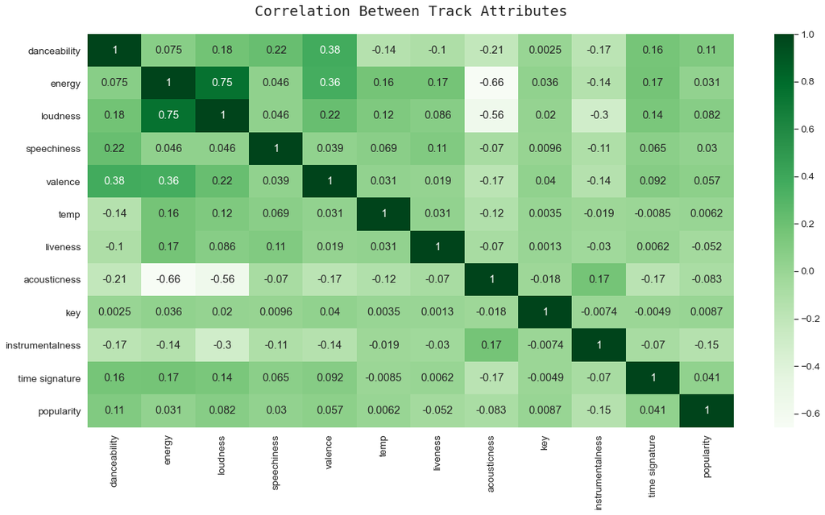

```python
# Taking only attribute columns from track data
heatmap_df = track_df.loc[:,'danceability':'popularity']

# Formatting font, size, title and ticks
font = {'fontname' : 'Monospace', 'fontsize' : '20', 'pad' : '25'}
sns.set(font_scale = 1.25)
plt.figure(figsize=(20, 10))
plt.title('Correlation Between Track Attributes', **font)

# Plotting the heatmap with annotations
sns.heatmap(heatmap_df.corr(), annot = True, cmap = "Greens")
plt.show()
```

#### Inference

From the above heatmap, we can observe the following:

- **Significant Positive Correlation**
  - **Loudness is positively correlated with Energy**
    - This is an expected outcome as songs that are more loud have more **bass and drums** involved in them. For example, a Rock track is more loud compared to a Pop track and is more energetic in nature. That could be the reason why people tend to listen to loud music whenever they are in a middle of some physical activity which requires strength and energy.
  - **Valence is positively correlated with Danceability**
    - As valence defines the happiness of a song, we can justify this observation by the fact that people tend to have happy music in their party playlists.
- **Significant Negative Correlation**
  - **Energy is negatively correlated with Acousticness**
    - This could be because acoustic songs tend have lesser instruments in them, thus they could lack the impact leading to lesser energy in them.
  - **Loudness is negatively correlated with Acousticness**
    - This could be because acoustic songs are recorded raw without any processing. Artists tend to increase the decible volume of the instruments during processing and production of the track.

What is shocking is that not a single attribute strongly correlates with popularity. May be just one attribute isn't enough to impact the popularity of the song. It could be possible for multiple attributes together to affect the popularity of the song. We will be digging deeper into it next.

### Attributes Affecting Artist Popularity

From the above analysis, we found out that no single track attribute majorly affects the popularity of the track. So, now we will try to look for some common attributes that makes an artist popular, if any. We will compare the attributes of 5 most popular and least popular artists in a form of a **radar chart**.

We will achieve this by following the below mentioned steps:

- Group all the songs of each artist
- Take average of the popularity of all the songs composed by them
- Sort them from highest to least popularity and choose the top and bottom 5 artists
- Choose song attributes which might be most relevant for an artist
- Plot a radar chart showing the comparison of the most and least popular artists based on the chosen attributes

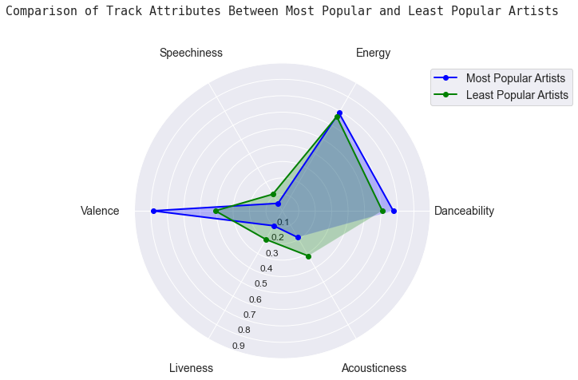

```python
# Creating the labels for radar chart
labels = ['danceability', 'energy', 'speechiness', 'valence', 'liveness', 'acousticness']

# Finding the mean values of lables created above for 5 most popular artists
popular_artist_df = track_df.groupby('artist_name').mean().sort_values('popularity', ascending = False).head(5)[labels].mean().to_list()
least_popular_artist_df = track_df.groupby('artist_name').mean().sort_values('popularity', ascending = False).tail(5)[labels].mean().to_list()

# Finding the mean values of lables created above
std_scaler = MinMaxScaler()
all_artist_df = track_df[labels]
df_scaled = std_scaler.fit_transform(all_artist_df.to_numpy())
df_scaled = pd.DataFrame(df_scaled)

all_artist_df = df_scaled.mean().to_list()

# Creating radar chart
angles = np.linspace(0, 2 * np.pi, len(labels), endpoint = False)
fig = plt.figure(figsize = (15,15))

# Plotting songs characteristic (mean) of songs by popular artists
ax = fig.add_subplot(221, polar = True)
ax.plot(angles, popular_artist_df, 'o-', linewidth = 2, label = "Most Popular Artists", color = 'blue')
ax.fill(angles, popular_artist_df, alpha = 0.25, facecolor = 'blue')

# Setting characteristics name on the plot
ax.set_thetagrids(angles * 180/np.pi, ['Danceability','Energy','Speechiness','Valence','Liveness','Acousticness'], fontsize=14)
ax.xaxis.set_tick_params(pad = 30)

# Creating labels for plot
ax.set_rlabel_position(250)
plt.yticks([0.1 , 0.2 , 0.3 , 0.4, 0.5,  0.6, 0.7, 0.8, 0.9], ["0.1",'0.2', "0.3", "0.4", "0.5", "0.6", '0.7', '0.8', '0.9'], size=12)
plt.ylim(0,0.9)

# Plotting songs characteristic (mean) of songs by all artists
ax.plot(angles, least_popular_artist_df, 'o-', linewidth = 2, label = "Least Popular Artists", color = 'green')
ax.fill(angles, least_popular_artist_df, alpha = 0.25, facecolor = 'green')
ax.grid(True)

# Displaying the plot
hfont = {'fontname':'Monospace','fontsize': 15}
ax.set_title('Comparison of Track Attributes Between Most Popular and Least Popular Artists', **hfont, pad = 60)
plt.legend(loc = 'best', bbox_to_anchor = (1.5, 1), fontsize = 14)
plt.show()
```

#### Inference

We can observe that people tend to love artists who produce songs which have **more energy and danceability**. This may be a hint towards people loving the **party genre**. We can also find that energy and danceability of all songs, regardless of artist popularity, are comparable. This could mean that these attributes are a common trait in the music industry. The liveness and Speachiness are not the influencing factors for audience's preferences. One major difference that we can see between most popular artists and least popular artists is the **Valence factor**. Valence defines the happiness in the song. We can observe that people tend to love songs that makes them feel positive and happy. These observations can act as a formula for new musicians trying to build up the their name in the music industry. They should consider making songs that are positive and energetic at the same time.

### Evolution of Sound over the Years

```python
# Load the dataframe
track_df = pd.read_csv('track_data.csv')
```

```python
# Copying the track dataframe to a genre dataframe
genre_df = track_df.copy()

# Determining average populartiy of all the tracks in the dataset
average_popularity = genre_df['popularity'].mean()

# Droping null values and convert the genre column to a list
genre_df.dropna(inplace=True)
genre_df['genre'] = genre_df['genre'].apply(lambda x: ast.literal_eval(x))

# Drop all duplicate tracks in a dataframe
genre_df.drop_duplicates(subset='track_uri', inplace=True)
genre_df = genre_df.explode(column='genre')

# If a track's popularity is greater than average popularity of all tracks then create a dummy variable as 1 and 0 as 'Hit Song' and 'Flop Song' respectively
genre_df['Hit or Flop'] = genre_df['popularity'].apply(lambda x: 1 if x>average_popularity else -1)

# Creating a dataframe with top 3 popular genres and least3 popular genres
top_3_genre_df = pd.DataFrame(genre_df.groupby('genre')['Hit or Flop'].sum()).sort_values(by='Hit or Flop', ascending=False).head(3)
bottom_3_genre_df = pd.DataFrame(genre_df.groupby('genre')['Hit or Flop'].sum()).sort_values(by='Hit or Flop', ascending=False).tail(3)
```

```python
# Displaying top 3 genres
top_3_genre_df
```

| genre | Hit or Flop |
| --- | --- |
| rap | 902 |
| hip hop | 675 |
| pop | 616 |

```python
# Displaying bottom 3 genres
bottom_3_genre_df
```

| genre | Hit or Flop |
| --- | --- |
| indie folk | -452 |
| stomp and holler | -456 |
| indie rock | -476 |

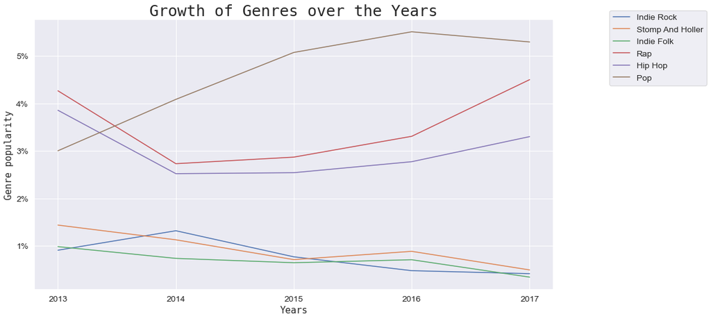

```python
# Merging the playlist dataframe and track dataframe on playlist id to populate tracks with the year they were added to the playlist and drop redundant columns
track_df = track_df.merge(playlist_df, on='pid')
track_df.drop(columns=['tracks','num_tracks','num_albums','num_followers','num_edits','name','collaborative','num_artists','duration_ms_y','duration_ms_x'],inplace=True)

# Droping the rows if there are any null values and type cast the genre column from string to list
track_df.dropna(inplace=True)
track_df['genre'] = track_df['genre'].apply(lambda x: ast.literal_eval(x))

# For every genre of a track, repeat the tracks individually for each genre
track_df= track_df.explode(column='genre')

# Counting the total number of genres that were in all the songs for all playlist every year
total_genre = pd.DataFrame(track_df.groupby('modified_year')['genre'].count())
total_genre.reset_index(inplace=True)

# Counting the individual genres by year
gen_count_year = pd.DataFrame(track_df.groupby('modified_year')['genre'].value_counts())
gen_count_year.rename(columns={'genre':'genre count'},inplace=True)
gen_count_year.reset_index(inplace=True)

# Merging the dataframes of individual genre count and total genre count by year
gen_count_year = gen_count_year.merge(total_genre, on='modified_year')

# Calculating the percentage of each genre as a proportion of total genre in a particular year
gen_count_year['percentage'] = (gen_count_year['genre count']/gen_count_year['genre_y'])*100
gen_count_year = gen_count_year[gen_count_year.modified_year != '2011']
gen_count_year = gen_count_year[gen_count_year.modified_year != '2012']

# Dropping columns which are not needed
gen_count_year.drop(columns=['genre count','genre_y'], inplace=True)
gen_count_year

# Creating individual dataframe for each genre that we want to visualize
indierock = gen_count_year[gen_count_year['genre_x'] == 'indie rock']
stompandhaller = gen_count_year[gen_count_year['genre_x'] == 'stomp and holler']
indiefolk = gen_count_year[gen_count_year['genre_x'] == 'indie folk']
rap = gen_count_year[gen_count_year['genre_x'] == 'rap']
hiphop = gen_count_year[gen_count_year['genre_x'] == 'hip hop']
pop = gen_count_year[gen_count_year['genre_x'] == 'pop']


# Plotting the line chart for the genres over the past 5 years to see if there are any trends
plt.figure(figsize=(15,8))
plt.plot(indierock['modified_year'], indierock['percentage'], label = "Indie Rock")
plt.plot(stompandhaller['modified_year'], stompandhaller['percentage'], label = "Stomp And Holler")
plt.plot(indiefolk['modified_year'], indiefolk['percentage'], label = "Indie Folk")
plt.plot(rap['modified_year'], rap['percentage'], label = "Rap")
plt.plot(hiphop['modified_year'], hiphop['percentage'], label = "Hip Hop")
plt.plot(pop['modified_year'], pop['percentage'], label = "Pop")
plt.legend(bbox_to_anchor=(1.1, 1.05))
hfont = {'fontname':'Monospace', 'fontsize':15,}
vfont = {'fontname':'Monospace', 'fontsize':25}
plt.gca().set_yticklabels(['{:.0f}%'.format(x*1) for x in plt.gca().get_yticks()])
plt.xlabel('Years', **hfont)
plt.ylabel('Genre popularity', **hfont)
plt.title('Growth of Genres over the Years', **vfont)
plt.show()
```

#### Inference

Genres like Indie Rock, Stomp and Haller, and Indie Folk are relatively niche and hence are declining rapidly in popularity over the years. However, the **Pop** genre has seen an incredible amount of growth starting from the year 2013. This could be because of the fact that in the year 2014, **Billboard** top teen pop artist - **Taylor Swift**, released her music on Spotify.

### Billboard Top 5 Artists

Taking into consideration the song attributes and artist popularity, we decided to look how this fits into the classification and rankings of artists. Using Billboard's Top Artists of the decade (2010 - 2020), we decided to filter the dataframe of our tracks to analyze how artists compare in popularity.

The Top Artists of the Decade were:

1. Drake
2. Taylor Swift
3. Bruno Mars
4. Rihanna
5. Ed Sheeran

Using Seaborn's **Violinplot**, we can visualize how Artist's compare in track popularity.

Source : [Billboard : Artist of the decade](https://www.kiro7.com/news/trending/artist-decade-drake-be-honored-during-2021-billboard-music-awards/PD4ZFQMLTNA6ZJKKCEKMFCOQS4/)

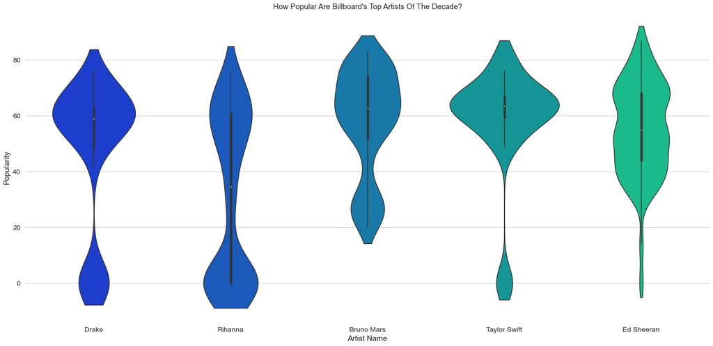

```python
# Grouping tracks by playlist ids (pid) and take the count
track_df['num_of_tracks'] = track_df.groupby('pid')['pid'].transform('count')

# Filling NA values by 0
track_df = track_df.fillna(0)

# Dropping duplicate tracks from the track dataframe
track_df.drop_duplicates(subset='track_uri', inplace=True)

# #Determining the average popularity of artist and sorting the tracks by playlist id
track_df['artist_pop'] = track_df.groupby('artist_name')['popularity'].transform('mean')
track_df = track_df.sort_values(by = 'pid').set_index('pid')
playlist_df = playlist_df.add_prefix('playlist_')

# Merge all songs df with playlist df
full_df = pd.merge(track_df, playlist_df, how = 'left', on = 'pid').drop(columns = ['playlist_tracks'])

# List of Billboard's Top Five Artist of the Decade
top_artists = ['Drake',
               'Taylor Swift',
               'Bruno Mars',
               'Rihanna',
               'Ed Sheeran']

# Filter songs df with only top artists
top_artists_full_df = full_df[full_df['artist_name'].isin(top_artists)].sort_values(by = 'num_of_tracks',
                                                                                    ascending = False)
# New dataframe with average values of top artists
avg_top_artists_full_df = top_artists_full_df.groupby('artist_name').mean().reset_index()

top_artists_full_df.rename(columns={'artist_name':'Artist Name','popularity':'Popularity'},inplace=True)
# Set style and graph dimensions
sns.set_style('whitegrid')
plt.figure(figsize = (20,10))
hfont = {'fontname':'Monospace','fontsize':22}
plt.tight_layout()

# Create violinplot for the song popularity of top artists
viol_plot = sns.violinplot(x ='Artist Name',
                           y ='Popularity',
                           data = top_artists_full_df,
                           palette = 'winter',
                           bw = .3,
                           cut = 1,
                           ).set(title = "How Popular Are Billboard's Top Artists Of The Decade?")

sns.set(font_scale = 2)
# Remove spines on x and y axis
sns.despine(left=True, bottom=True)
plt.tight_layout()
```

#### Inference

The top artist of decade, according to Billboard, was Drake. At first glance we can observe that Drake has popular tracks that are lower than some of the top 5 artists. We can see the Bruno Mars and Taylor Swift had high track popularity, and few tracks that were unpopular. Rihanna and Drake had more tracks that can be considered unpopular.

### Recommendation System

We not only have a clear understanding of how we can differentiate each song from the rest by quantifying its attributes but we also know what sound users are looking for and how that sound is changing every year. We have also analyzed attributes of artists who are on top of their game and are preferred by users based on number of times they have been added by them in their playlists. These analysis gives us enough knowledge to build a recommendation system to personalize user experience.

To achieve this, we will first remove all the duplicate tracks from the dataset and convert the genres from string to arrays in order to analyze genres. We will match the genre of the input track and compare it to the tracks with similar genre and then find a cosine similarity on track attributes which will give us a list of similar sounding tracks of the same genre.

**Cosine similarity** will be used to find similarity between two non-zero vectors. Our two non-zero vectors will be the songs metadata (input song and target song). We find this similarity by calculating the angle between these two vectors.

Mathematically, **Cosθ = A . B / ||A| . ||B||**

We will also be using **hamilton similarity** to make our recommendations even more accurate. We will also be taking care of the edge case testing.

```python
# Dropping duplicates and converting genre string into array of genres
track_df = pd.read_csv(r'track_data.csv')
track_df.drop_duplicates(subset='track_uri', keep='first', inplace=True)
track_df.dropna(inplace=True)
track_df['genre'] = track_df['genre'].apply(lambda x: ast.literal_eval(x))
```

```python
def cosine_similarity(row, song_row):

    ''' Cosine similarity will help us find a similarity matrix between our song metadata and give us a similarity score '''

    if row['genre']:
        if not set(song_row['genre'].iloc[0]).isdisjoint(row['genre']):
            song_metadata = song_row.loc[:, 'danceability':'popularity'].values.reshape(-1, 1)
            cs_song_metadata = row['danceability':'popularity'].values.reshape(-1, 1)
            return 1 - spatial.distance.cosine(song_metadata, cs_song_metadata)
    return -1

def hamilton_similarity(row, song_row):

    ''' Hamilton similarity like cosine similarity will help us find a matrix between our song metadata
    and give us a similarity score. This will be an added comparison on top of cosine similarity '''

    if row['genre']:
        if not set(song_row['genre'].iloc[0]).isdisjoint(row['genre']):
            song_metadata = song_row.loc[:, 'danceability':'popularity'].values.reshape(-1, 1)
            hs_song_metadata = row['danceability':'popularity'].values.reshape(-1, 1)
            return spatial.distance.hamming(song_metadata, hs_song_metadata)
    return -1
```

```python
def song_input(recommend_df):

    ''' Taking input of the first song and its respective artist and iterating our dataframe to match the input '''

    song_name = input('Enter the Song Name  ')
    artist_name = input('Enter the Artist Name  ')
    song_row = recommend_df.loc[
        (recommend_df['track_name'].str.lower() == song_name.lower()) & (recommend_df['artist_name'].str.lower() == artist_name.lower())]
    if song_row.empty:
        print("The Song-Artist Combination does not exist. Please input again\n")
        song_input(recommend_df)
    recommendation(song_row)
```

```python
def recommendation(song_row):

    ''' our dataset will first be sorted on Cosine and then on hamilton similarity '''

    track_df['cosine_similarity'] = track_df.apply(cosine_similarity, args=(song_row.head(1),), axis=1)
    track_df['hamilton_similarity'] = track_df.apply(hamilton_similarity, args=(song_row.head(1),), axis=1)
    track_df.sort_values(['cosine_similarity', 'hamilton_similarity'], inplace=True, ascending=[False, False])
    pd.set_option('display.max_columns', None)
    top_songs = track_df.head(20)
    print('Your recommended playlist based on your song choice: \n')
    display(top_songs.reset_index()[['track_name', 'artist_name']])
```

```python
try:
    song_input(track_df)
except Exception as Fault:
    error = Fault
```

```
Your recommended playlist based on your song choice:
```

|  | track_name | artist_name |
| --- | --- | --- |
| 0 | Enter Sandman | Metallica |
| 1 | Afraid To Shoot Strangers - 1998 Remastered Ve... | Iron Maiden |
| 2 | The Unforgiven | Metallica |
| 3 | Merry Xmas Everybody | Slade |
| 4 | No Particular Place To Go | Chuck Berry |
| 5 | The Power Of Love | Huey Lewis & The News |
| 6 | Do It Again | The Kinks |
| 7 | Baba O'Riley | The Who |
| 8 | With A Little Help From My Friends - Take 1 / ... | The Beatles |
| 9 | Come Dancing | The Kinks |
| 10 | He's Evil | The Kinks |
| 11 | Congratulations | MGMT |
| 12 | Runnin' Down A Dream | Tom Petty |
| 13 | Honky Tonk Women - Mono Version | The Rolling Stones |
| 14 | Tongues | Joywave |
| 15 | Like A Friend | Pulp |
| 16 | Come Together - Remastered | The Beatles |
| 17 | Who Are You | The Who |
| 18 | Anything You Want | Spoon |
| 19 | Run | AWOLNATION |

#### Scope of Improvement

We can further optimize our recommendation system based on the user listening history and not just the playlist data. We can also optimize this recommendation system by using similar playlists of different users.

## Conclusion

To wrap it up, We have analyzed how we could quantify the tracks based on different metrics. Through this, we found out that these metrics are not individually related to the popularity of the song. However, from our second analysis we can see that the artists who are popular tend to have specific attributes in their song. These attributes are:

- Danceability
- Valence
- Energy This analysis could help upcoming artist to follow this formula by including these metrics in their song to make up their name in the music industry.

We then analyzed the data for top Billboard artists to see if the music industry is relying completely on spotify streams to judge the performance of an artist. From the analysis, we can infer that even though everything is going digital, artist popularity defined by Spotify is not the only factor to determine artist's popularity. Maybe Billboard are considering other factors like tour ticket sale, physical distribution of music, streams from other platforms in order to calculate the popularity of the artist.

After having enough knowledge about the music industry and attributes, we decided to make our own recommendation system to personalize user experience. This recommendation system can be used by any digital platform who wishes to provide a hyper personalized environment to their users.